# MQTT for Sensor Networks Version 2.0

## 4.14 Client states

At any time, a Client will be in one of the following states from the perspective of the Server:

*Figure 4-7 -- Client States*

| State | State Description | Possible Transitions |
| --- | --- | --- |
| **None** | The Client is unknown to the Server. There is no Session State nor Virtual Connection. A Client may transition from here to **Active** with a CONNECT. | **Active** |
| **Disconnected** | The Client is considered offline and not able to receive packets until it has re-established a session with the Server by way of a CONNECT. The Server has Session state for this Client, but there is n… | **Active** **None** |
| **Active** | The Client is actively engaged in the Session. A Virtual Connection exists. It should be able to send and receive packets. Its state is supervised by the Server with the associated Keep Alive timer. A… | **Asleep** **Disconnected** |
| **Asleep** | The Client is engaged in an ongoing Session, and a Virtual Connection exists. The Client cannot receive Packets (except possibly the WAKEUP hint); it can send Packets. The Server should not expect a r… | **Awake** **Active** **Disconnected** |
| **Awake** | The Client is partially engaged in an ongoing session and a Virtual Connection exists. The client transitions back to the **Asleep** state on receipt of a PINGRESP packet or **Disconnected** (by way o… | **Asleep** **Active** **Disconnected** |

Table: Client States

«A Server **MUST NOT** attempt to send packets to a Disconnected Client»[MQTT‑SN‑4.14‑1].

«Any packet except CONNECT received from a Disconnected Client MUST NOT be processed»[MQTT‑SN‑4.14‑2]. A DISCONNECT with error should be sent in response, unless the packet received is PUBWOS.

«In the Asleep state, a Client MUST only send PINGREQ, CONNECT or DISCONNECT packets to the Server»[MQTT‑SN‑4.14‑3].

«In the Awake state, a Client MUST not send ANY packets other than those involved in the receipt of PUBLISH packets (PUBACK, PUBREC, PUBCOMP, REGACK) or CONNECT or DISCONNECT»[MQTT‑SN‑4.14‑4].

«Whenever a CONNECT is received by a Server, any existing Virtual Connection for that Client MUST be deleted and a new one created with all CONNECT Packet processing, regardless of the state of the Client»[MQTT‑SN‑4.14‑5].

Transition through these states is governed by a sequence of packets between Client and Server and mediated by [timers] resident on the Server. A Client is in the Active state when the Server receives a CONNECT packet from that Client. This state is supervised by the Server with the 3.1.6 Keep Alive timer. If the Server does not receive any packet from the Client in a defined period, the Server will consider that client as Disconnected and delete the Virtual Connection. The Disconnected state is governed by the Session Expiry timer - on expiry the Server is free to remove the Client session. A Client moves into the Asleep state by issuing a SLEEPREQ packet. To be certain that the Server has also recorded the Client as being asleep, the Client needs to wait for a positive SLEEPRESP response. For more information on the Asleep state, refer to 4.14.2 Sleeping Clients.

See C.5 Client State Diagrams for informative state diagrams to help illustrate these transitions.

> **Informative Comment**

> In MQTT-SN 1.2 there existed a Lost state, which was identical to the Disconnected state, except that it was reached by a timer expiry on the Server rather than an explicit Disconnect request from the Client. As the Lost state was not really different from Disconnected except for the history of Client events, similar information may be kept by the Server, in for instance its administrative logs.

### 4.14.1 Session Timers

The following timers are used by Servers, on a per Client basis, to handle Client states, and by Clients to direct their actions. In general, Clients are able to infer the Server's view of their state by observing the Server's response.

*Figure 4-8 -- Session Timers*

| Timer Name | State(s) | Timeout State | Defined in | Information |
| --- | --- | --- | --- | --- |
| Keep Alive | Active | Disconnected | CONNECT | 3.1.6 Keep Alive |
| Sleep Duration | Asleep | Disconnected | SLEEPREQ | 4.14.2 Sleeping Clients |
| Session Expiry | Disconnected | None | CONNECT, DISCONNECT | 4.1.1 Storing Session State |
| Retry | Active, Awake, Asleep | Disconnected | Sender configuration | 4.4 Packet delivery retry |

Table: Session Timers

For example values of these timers, see C.3 Example Timer and Counter Values.

### 4.14.2 Sleeping Clients

The Asleep state is intended to allow Clients, which may be running on battery powered devices, to save as much energy as possible. These Clients enter a low-power mode when they are not active, and will wake when they have data to send or receive. The Server needs to be aware of the sleeping state of these Clients and buffer messages destined for them, so that they may be delivered when the Clients wake up.

To go to sleep, a Client sends a SLEEPREQ packet containing a Sleep Duration in seconds. The Server acknowledges that packet with a SLEEPRESP Packet including a successful Reason Code, and considers the Client to be Asleep.

«During the Asleep state, packets that need to be sent to the client are buffered at the Server. The Server MUST buffer Application Messages of QoS 1 and 2»[MQTT‑SN‑4.14.2‑2].

> **Informative comment**

> The Server may *choose* to buffer messages of QoS 0 while the Client is in the Asleep state.

The Client wakes by sending a PINGREQ. If the Server has buffered packets for the Client, it will send them to the Client, acknowledging the Default Awake Messages value sent in the CONNECT packet. «If the number of messages buffered on the Server waiting to be sent exceeds the value specified by the client in the Default Awake Messages field, the Server MUST send only the Default Awake Messages value number of messages»[MQTT‑SN‑4.14.2‑3].

«It cuts short the AWAKE cycle, and MUST respond with a PINGRESP with a messages-left value of either the number of messages remaining in the Server buffer or 0xFFFF (meaning undetermined number of messages greater than 0 remaining)»[MQTT‑SN‑4.14.2‑4].

«During the Awake state, for each Application Message the Server sends to the Client, the application messages' quality of service MUST be honored - a full packet interaction MUST take place including all normative phases of acknowledgement, including any associated retransmission logic»[MQTT‑SN‑4.14.2‑5].

«If, during the delivery of Application Messages from the Server to the Client, and applying the [retry logic]](#unacknowledged-packets), the Server gets no response, it MUST consider the Client disconnected and delete the Virtual Connection»[MQTT‑SN‑4.14.2‑6]. [It may send a DISCONNECT packet with an appropriate Reason Code.

The transfer of packets to the Client is closed by the Server by means of a PINGRESP packet. That is, the Server will consider the Client as Asleep and restart the Sleep Duration timer after having sent the PINGRESP packet. «If the Server does not have any packets buffered for the client, it MUST respond immediately with a PINGRESP packet»[MQTT‑SN‑4.14.2‑7], returning the Client back to the Asleep state, and restarting the Sleep Duration timer for that Client.

After having sent the PINGREQ to the Server, the Client uses the retransmission procedure of 4.4 Packet delivery retry to supervise the arrival of packets sent by the Server. To avoid draining its battery due to excessive retransmission of the PINGREQ packet, the Client should limit the retransmission with a Maximum Retry Count, and go back to sleep when the limit is reached.

At some point after several Awake periods without any response from the Server, a Client might decide that it needs to try to connect to a different Server. The Client might send a DISCONNECT Packet to try to notify the original Server, or just delete its Virtual Connection.

From the *Asleep* state, a client can move to the *Active* state by sending a CONNECT packet or to the *Disconnected* state by sending a DISCONNECT packet. The Client can also modify its sleep configuration by sending a SLEEPREQ Packet with a new value of Sleep Duration.

Note that a sleeping Client should go to the *Awake* state only if it wants to check whether the Server has any Application Messages buffered for it and return as soon as possible to the *Asleep* state without sending any packets to the Server (other than PUBACK, PUBREC, PUBCOMP or REGACK). If it wants to do more than this, it needs to create a new Virtual Connection by sending a CONNECT packet to the Server.

Session Topic Aliases last for the duration of a Session which exists throughout the sleep cycle. However, if the Client wants to save storage by removing the Session Topic Aliases while Asleep, it can set the Retain Topic Aliases flag on the SLEEPREQ packet to 0. The disadvantage being that during the Awake state, Session Topic Aliases will have to be recreated, or Topic Names used instead, increasing network data usage.

*Figure 4-9 -- Awake PINGRESP Packet flush*

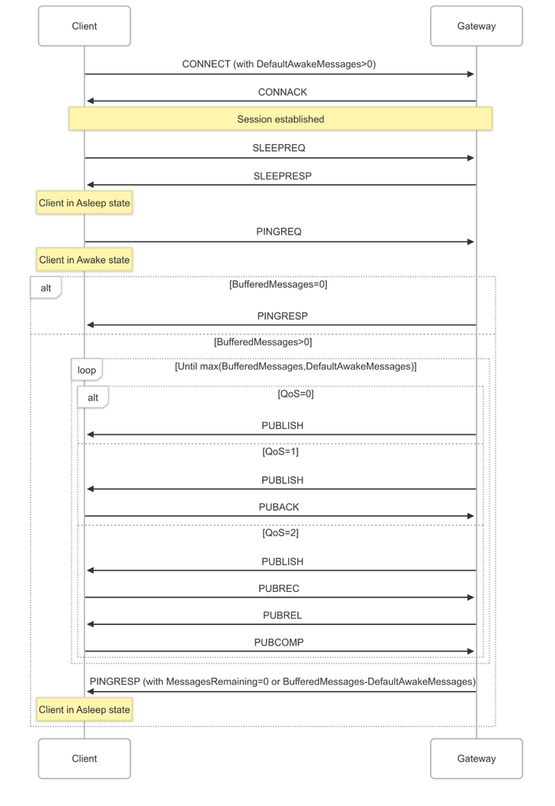

## 4.15 Optional Features

Support for the ADVERTISE, SEARCHGW, GWINFO and PUBWOS packet types is optional.

The Forwarder Encapsulation packet type support is optional. For instance, it is not required if the MQTT-SN Clients are able to directly reach an MQTT-SN Server.

The Protection Encapsulation packet type support is optional. For instance, it is not required if the MQTT-SN Server and the MQTT-SN Clients interact over a secure communication channel, such as DTLS, or any communication channel assuring the authenticity and optionally the confidentiality of MQTT-SN data.

# 5 Security (Informative)

## 5.1 Introduction

MQTT-SN is a transport protocol specification for message transmission, allowing implementers a choice of network, privacy, authentication and authorization technologies. Since the exact security technologies chosen will be context specific, it is the implementer's responsibility to include the appropriate features as part of their design.

MQTT-SN solutions are likely to also include MQTT communications - this section should be read alongside the Security chapters in the MQTT standards: [[MQTT 3.1.1]](https://docs.oasis-open.org/mqtt/mqtt/v3.1.1/os/mqtt-v3.1.1-os.html) and [[MQTT 5.0]](https://docs.oasis-open.org/mqtt/mqtt/v5.0/mqtt-v5.0.html).

MQTT-SN implementations will likely need to keep pace with an evolving security landscape. This Chapter provides general implementation guidance so as not to restrict choices available. Examples of threats that solution providers should consider are:

- Devices could be compromised
- Data at rest in Clients and Servers might be accessible
- Protocol behaviors could have side effects - "timing attacks" for example
- Denial of Service (DoS) attacks
- Communications could be intercepted, altered, re-routed or disclosed
- Injection of spoofed MQTT-SN Control Packets

When MQTT-SN solutions are deployed in hostile communication environments, implementations will often need to provide mechanisms for:

- Authentication of users and devices
- Authorization of access to Server resources
- Integrity of MQTT-SN Control Packets and application data contained therein
- Privacy of MQTT-SN Control Packets and application data contained therein

In addition to technical security issues there could also be geographic (for example U.S.-EU Privacy Shield Framework [[[USEUPRIVSH]]](https://docs.oasis-open.org/mqtt/mqtt/v5.0/cos02/mqtt-v5.0-cos02.html#USEUPRIVSH)), industry specific (for example PCI DSS [[[PCIDSS]]](https://docs.oasis-open.org/mqtt/mqtt/v5.0/cos02/mqtt-v5.0-cos02.html#PCIDSS)) and regulatory considerations (for example Sarbanes-Oxley [[[SARBANES]]](https://docs.oasis-open.org/mqtt/mqtt/v5.0/cos02/mqtt-v5.0-cos02.html#SARBANES)).

## 5.2 MQTT-SN solutions: security and certification

An implementation might want to provide conformance with specific industry security standards such as NIST Cyber Security Framework [[[NISTCSF]]](https://docs.oasis-open.org/mqtt/mqtt/v5.0/cos02/mqtt-v5.0-cos02.html#NISTCSF), PCI-DSS [[[PCIDSS]]](https://docs.oasis-open.org/mqtt/mqtt/v5.0/cos02/mqtt-v5.0-cos02.html#PCIDSS)), FIPS-140-3 [[[FIPS1403]]](https://docs.oasis-open.org/mqtt/mqtt/v5.0/cos02/mqtt-v5.0-cos02.html#FIPS1402) and Commercial National Security Algorithm Suite (CNSA) 2.0 [[[CNSA20]]](https://media.defense.gov/2022/Sep/07/2003071834/-1/-1/0/CSA_CNSA_2.0_ALGORITHMS_.PDF). The use of industry proven, independently verified and certified technologies will help meet compliance requirements.

## 5.3 Lightweight cryptography and constrained devices

MQTT-SN is targeted at the most power saving and constrained devices. In contrast to MQTT where there is principally one underlying network technology - TCP/IP - MQTT-SN is intended to be agnostic to the underlying network as long as it conforms to the requirements outlined in [4.2 Networks and Virtual Connections].

Previous versions of MQTT-SN did not include specific security and integrity features, preferring to leave that to the underlying network. That approach is still supported, but to aid interoperability the Protection Encapsulation is introduced, in [3.17 Protection Encapsulation]. In order to disassociate the security model from the rest of the MQTT-SN specification, the Protection Encapsulation allows all the packet types, including CONNECT, to be wrapped in a security envelope. Furthermore the security material is self-contained in each Protection Encapsulation envelope, so it is completely decoupled from the Virtual Connection.

The schemes defined by the Protection Encapsulation are especially suited for implementation by constrained devices:

- HMAC and AES CMAC are widely adopted authentication only standard schemes.
- The Advanced Encryption Standard [[[AES]]](https://docs.oasis-open.org/mqtt/mqtt/v5.0/cos02/mqtt-v5.0-cos02.html#AES) is the most widely adopted encryption algorithm. There is hardware support for AES in many processors, but not commonly for embedded processors.
- The encryption algorithm ChaCha20 [[[CHACHA20]](https://docs.oasis-open.org/mqtt/mqtt/v5.0/cos02/mqtt-v5.0-cos02.html#CHACHA20)] encrypts and decrypts much faster in software, but is not as widely available as AES.

The Protection Encapsulation approach is informed by the OSCORE [RFC 8613] standard and CBOR Initial Algorithms [RFC 9053] informational document. The ISO 29192 [[[ISO29192]]](https://docs.oasis-open.org/mqtt/mqtt/v5.0/cos02/mqtt-v5.0-cos02.html#ISO29192) standard makes recommendations for cryptographic primitives specifically tuned to perform on constrained, low end, devices.

The MQTT-SN Protection Encapsulation also allows for user defined protection schemes, although these will of necessity have lower interoperability compared to the built-in schemes, as implementations of both Client and Server will have to be aware of them.

## 5.4 Implementation notes

When the underlying network layer for MQTT-SN is UDP, DTLS [RFC9147] can be used to secure MQTT-SN communications instead of or in conjunction with the Protection Encapsulation. It is recommended that Server implementations that offer DTLS use UDP port 8883 (IANA service name: secure-mqtt).

For other underlying network technologies, a security solution particular to that technology must be found, which could involve using the MQTT-SN [Protection Encapsulation] and/or [Authentication].

There are many security concerns to consider when implementing or using MQTT-SN. The following section should not be considered a comprehensive checklist.

An implementation might want to achieve some, or all, of the following:

### 5.4.1 Authentication of Clients by the Server

The CONNECT packet contains an Authentication Data field which can contain a user name and password if the Authentication Method is SASL PLAIN (see [4.11.1.2 MQTT User Name and Password Support]). Implementations can choose how to make use of the content of these fields. They may provide their own authentication mechanism, use an external authentication system such as LDAP [[[RFC4511]]](https://docs.oasis-open.org/mqtt/mqtt/v5.0/cos02/mqtt-v5.0-cos02.html#RFC4511) or OAuth [[[RFC6749]]](https://docs.oasis-open.org/mqtt/mqtt/v5.0/cos02/mqtt-v5.0-cos02.html#RFC6749) tokens, or leverage operating system authentication mechanisms.

MQTT-SN provides an Authentication mechanism as described in [4.11 Authentication]. Using this requires support for it in both the Client and Server.

Implementations passing authentication data in clear text, obfuscating such data elements or requiring no authentication data should be aware this can give rise to Man-in-the-Middle and replay attacks. [5.4.5 Privacy of Application Messages and MQTT-SN Control Packets] introduces approaches to ensure data privacy.

A Virtual Private Network (VPN) between the Clients and Servers can provide confidence that data is only being received from authorized Clients.

Where DTLS [[[RFC9147]]](https://datatracker.ietf.org/doc/rfc9147/) is used, X.509 Certificates sent from the Client can be used by the Server to authenticate the Client to achieve mutual authentication.

### 5.4.2 Authorization of Clients by the Server

If a Client has been successfully authenticated, a Server implementation should check that it is authorized before accepting its connection.

Authorization may be based on information provided by the Client such as User Name, the hostname/network address of the Client, or the outcome of authentication mechanisms.

In particular, the implementation should check that the Client is authorized to use the Client Identifier as this gives access to the MQTT-SN Session State (described in [4.1 Session state]). This authorization check is to protect against the case where one Client, accidentally or maliciously, provides a Client Identifier that is already being used by some other Client.

An implementation should provide access controls that take place after CONNECT to restrict the Client's ability to publish to particular Topics or to subscribe using particular Topic Filters. An implementation should consider limiting access to Topic Filters that have broad scope, such as the # Topic Filter.

### 5.4.3 Authentication of the Server by the Client

The MQTT-SN protocol is not trust symmetrical. When using basic Username and Password authentication, there is no mechanism for the Client to authenticate the Server. Some forms of authentication do allow for mutual authentication.

Where DTLS is used, X.509 Certificates sent from the Server can be used by the Client to authenticate the Server.

MQTT-SN provides an Authentication mechanism as described in [4.11 Authentication], which can be used to authenticate the Server to the Client. Using this requires support for it in both the Client and Server.

A VPN between Clients and Servers can provide confidence that Clients are connecting to the intended Server.

### 5.4.4 Integrity of Application Messages and MQTT-SN Control Packets

Applications can independently include hash values in their Application Messages. This can provide integrity of the contents of Publish packets across the network and at rest.

DTLS and the Protection Encapsulation provide hash algorithms to verify the integrity of data sent over the network.

The use of VPNs to connect Clients and Servers can provide integrity of data across the section of the network covered by a VPN.

### 5.4.5 Privacy of Application Messages and MQTT-SN Control Packets

DTLS [[[RFC9147]]](https://datatracker.ietf.org/doc/rfc9147/) can provide encryption of data sent over the network. There are valid DTLS cipher suites that include a NULL encryption algorithm that does not encrypt data. To ensure privacy Clients and Servers should avoid these cipher suites.

An application might independently encrypt the contents of its Application Messages. This could provide privacy of the Application Message both over the network and at rest. This would not provide privacy for other Properties of the Application Message such as Topic Name.

Client and Server implementations can provide encrypted storage for data at rest such as Application Messages stored as part of a Session.

The use of VPNs to connect Clients and Servers can provide privacy of data across the section of the network covered by a VPN.

### 5.4.6 Non-repudiation of message transmission

Application designers might need to consider appropriate strategies to achieve end to end non-repudiation.

### 5.4.7 Detecting compromise of Clients and Servers

Client and Server implementations using DTLS should provide capabilities to ensure that any X.509 certificates provided when initiating a DTLS session are associated with the hostname of the Client connecting or Server being connected to.

Client and Server implementations using DTLS can choose to provide capabilities to check Certificate Revocation Lists (CRLs [[[RFC5280]]](https://docs.oasis-open.org/mqtt/mqtt/v5.0/cos02/mqtt-v5.0-cos02.html#RFC5280)) and Online Certificate Status Protocol (OSCP) [[[RFC6960]]](https://docs.oasis-open.org/mqtt/mqtt/v5.0/cos02/mqtt-v5.0-cos02.html#RFC6960) to prevent revoked certificates from being used.

Physical deployments might combine tamper-proof hardware with the transmission of specific data in Application Messages. For example, a meter might have an embedded GPS to ensure it is not used in an unauthorized location. [[[IEEE8021AR]]](https://docs.oasis-open.org/mqtt/mqtt/v5.0/cos02/mqtt-v5.0-cos02.html#IEEE8021AR) is a standard for implementing mechanisms to authenticate a device's identity using a cryptographically bound identifier.

### 5.4.8 Detecting abnormal behaviors

Server implementations might monitor Client behavior to detect potential security incidents. For example:

- Repeated connection attempts
- Repeated authentication attempts
- Abnormal termination of connections
- Topic scanning (attempts to send or subscribe to many topics)
- Sending undeliverable messages (no subscribers to the topics)
- Clients that connect but do not send data

Server implementations might delete the Virtual Connection of Clients that breach its security rules.

Server implementations detecting unwelcome behavior might implement a dynamic block list based on identifiers such as IP address or Client Identifier.

Deployments might use network-level controls (where available) to implement rate limiting or blocking based on IP address or other information.

### 5.4.9 Handling of Disallowed Unicode code points

[1.7.4 UTF-8 Encoded String] describes the Disallowed Unicode code points, which should not be included in a UTF-8 Encoded String. A Client or Server implementation can choose whether to validate that these code points are not used in UTF-8 Encoded Strings such as the Topic Name or Properties.

If the Server does not validate the code points in a UTF-8 Encoded String but a subscribing Client does, then a second Client might be able to cause the subscribing Client to delete the Virtual Connection by publishing on a Topic Name or using Properties that contain a Disallowed Unicode code point. This section recommends some steps that can be taken to prevent this problem.

A similar problem can occur when the Client validates that the payload matches the Payload Format Indicator and the Server does not. The considerations and remedies for this are similar to those for handling Disallowed Unicode code points.

#### 5.4.9.1 Considerations for the use of Disallowed Unicode code points

An implementation would normally choose to validate UTF-8 Encoded strings, checking that the Disallowed Unicode code points are not used. This avoids implementation difficulties such as the use of libraries that are sensitive to these code points, it also protects applications from having to process them.

Validating that these code points are not used removes some security exposures. There are possible security exploits which use control characters in log files to mask entries in the logs or confuse the tools which process log files. The Unicode Noncharacters are commonly used as special markers and allowing them into UTF-8 Encoded Strings could permit such exploits.

#### 5.4.9.2 Interactions between Publishers and Subscribers

The publisher of an Application Message normally expects that the Servers will forward the message to subscribers, and that these subscribers are capable of processing the messages.

These are some conditions under which a publishing Client can cause the subscribing Client to delete the Virtual Connection. Consider a situation where:

- A Client publishes an Application Message using a Topic Name containing one of the Disallowed Unicode code points.
- The publishing Client library allows the Disallowed Unicode code point to be used in a Topic Name rather than rejecting it.
- The publishing Client is authorized to send the publication.
- A subscribing Client is authorized to use a Topic Filter which matches the Topic Name. Note that the Disallowed Unicode code point might occur in a part of the Topic Name matching a wildcard character in the Topic Filter.
- The Server forwards the message to the matching subscriber rather than disconnecting the publisher.
- In this case the subscribing Client might:
  - Delete the Virtual Connection because it does not allow the use of Disallowed Unicode code points, possibly sending a DISCONNECT before doing so. For QoS 1 and QoS 2 messages this might cause the Server to send the message again, causing the Client to delete the Virtual Connection again.
  - Reject the Application Message by sending a Reason Code greater than or equal to 0x80 in a PUBACK (QoS 1) or PUBREC (QoS 2).
  - Accept the Application Message but fail to process it because it contains one of the Disallowed Unicode code points.
  - Successfully process the Application Message.

The potential for the Client to delete the Virtual Connection might go unnoticed until a publisher uses one of the Disallowed Unicode code points.

#### 5.4.9.3 Remedies

If there is a possibility that a Disallowed Unicode code point could be included in a Topic Name or other Properties delivered to a Client, the solution owner can adopt one of the following suggestions:

1. Change the Server implementation to one that rejects UTF-8 Encoded Strings containing a Disallowed Unicode code point either by sending a Reason Code greater than or equal to 0x80 or deleting the Virtual Connection.
2. Change the Client library used by the subscribers to one that tolerates the use of Disallowed Code points. The client can either process or discard messages with UTF-8 Encoded Strings that contain Disallowed Unicode code points so long as it continues the protocol.

### 5.4.10 Other security considerations

If Client or Server X.509 certificates are lost or it is considered that they might be compromised they should be revoked (using CRLs [[[RFC5280]]](https://docs.oasis-open.org/mqtt/mqtt/v5.0/cos02/mqtt-v5.0-cos02.html#RFC5280) and/or OSCP [[[RFC6960]]](https://docs.oasis-open.org/mqtt/mqtt/v5.0/cos02/mqtt-v5.0-cos02.html#RFC6960)).

Client or Server authentication credentials, such as User Name and Password, that are lost or considered compromised should be revoked and/or reissued.

In the case of long lasting connections:

- Where applicable, Client and Server implementations should allow for session renegotiation to establish new cryptographic parameters (replace session keys, change cipher suites, change authentication credentials).
- Servers may close the Virtual Connection of Clients and require them to re-authenticate with new credentials.
- Servers may require their Client to reauthenticate periodically using the mechanism described in [4.11.1.1 Re-authentication].

Clients connected to a Server have a transitive trust relationship with other Clients connected to the same Server and who have authority to publish data on the same topics.

### 5.4.11 Use of SOCKS

Implementations of Clients should be aware that some environments will require the use of SOCKSv5 [[[RFC1928]]](https://docs.oasis-open.org/mqtt/mqtt/v5.0/cos02/mqtt-v5.0-cos02.html#RFC1928) proxies to transmit data. Some MQTT-SN implementations could make use of alternative secured tunnels through the use of SOCKS. Where implementations choose to use SOCKS, they should support both anonymous and User Name, Password authenticating SOCKS proxies. In the latter case, implementations should be aware that SOCKS authentication might occur in plain-text and so should avoid using the same credentials for connection to an MQTT-SN Server.

### 5.4.12 Security profiles

Implementers and solution designers might wish to consider security as a set of profiles which can be applied to the MQTT-SN protocol. An example of a layered security hierarchy is presented below.

#### 5.4.12.1 Clear communication profile

When using the clear communication profile, the MQTT-SN protocol runs over an open network with no additional secure communication mechanisms in place.

#### 5.4.12.2 Secured network communication profile

When using the secured network communication profile, the MQTT-SN protocol runs over a physical or virtual network which has security controls, VPNs or physically secure networks for example.

#### 5.4.12.3 Secured transport profile

When using the secured transport profile, the MQTT-SN protocol runs over a physical or virtual network and uses MQTT-SN Authentication, Protection Encapsulation, DTLS and/or other technologies to provide authentication, integrity and privacy.

DTLS Client authentication can be used in addition to -- or in place of -- MQTT-SN Client authentication as provided by the Authentication Method and Data fields.

#### 5.4.12.4 Industry specific security profiles

It is anticipated that the MQTT-SN (and MQTT) protocols will be designed into industry specific application profiles, each defining a threat model and the specific security mechanisms to be used to address these threats. Recommendations for specific security mechanisms will often be taken from existing works including:

[[NISTCSF] NIST Cyber Security Framework  
[NIST7628] NISTIR 7628 Guidelines for Smart Grid Cyber Security  
[FIPS1403] Security Requirements for Cryptographic Modules (FIPS PUB 140-3)  
[PCIDSS] PCI-DSS Payment Card Industry Data Security Standard  
[[CNSA20]](https://media.defense.gov/2022/Sep/07/2003071834/-1/-1/0/CSA_CNSA_2.0_ALGORITHMS_.PDF)] Commercial National Security Algorithm Suite (CNSA) 2.0

[NSAB] NSA Suite B Cryptography

# 6 Conformance

The MQTT specification defines conformance for MQTT Client implementations and MQTT Server implementations. An MQTT implementation can conform as both an MQTT Client and an MQTT Server.

## 6.1 Conformance clauses

### 6.1.1 MQTT-SN Server conformance clause

Refer to 1.4 Terminology for a definition of Server.

An MQTT-SN Server conforms to this specification only if it satisfies all the statements below:

1. The format of all MQTT-SN Control Packets that the Server sends matches the format described in 2 MQTT-SN Control Packet format and 3 MQTT-SN Control Packets.
2. It follows the Topic matching rules described in 4.7.1 Topic Names and Topic Filters and the Subscription rules in 4.8 Subscriptions.
3. It satisfies the MUST level requirements in the following chapters that are identified except for those that only apply to the Client:
   - 1 Introduction
   - 2 MQTT-SN Control Packet format
   - 3 MQTT-SN Control Packets
   - 4 Operational behavior
4. It does not require the use of any extensions defined outside of the specification in order to interoperate with any other conformant implementation.

### 6.1.2 MQTT-SN Client conformance clause

Refer to 1.4 Terminology for a definition of Client.

An MQTT-SN Client conforms to this specification only if it satisfies all the statements below:

1. The format of all MQTT-SN Control Packets that the Client sends matches the format described in 2 MQTT-SN Control Packet format and 3 MQTT-SN Control Packets.
2. It follows the Topic matching rules described in 4.7.1 Topic Names and Topic Filters and the Subscription rules in 4.8 Subscriptions.
3. It satisfies the MUST level requirements in the following chapters that are identified except for those that only apply to the Server:
   - 1 Introduction
   - 2 MQTT-SN Control Packet format
   - 3 MQTT-SN Control Packets
   - 4 Operational behavior
4. It does not require the use of any extensions defined outside of the specification in order to interoperate with any other conformant implementation.

# Appendix A. Acknowledgments

[Required section.]

Note: A Work Product approved by the TC must include a list of people who participated in the development of the Work Product. This is generally done by collecting the list of names in this appendix. This list shall be initially compiled by the Chair, and any Member of the TC may add or remove their names from the list by request.

Remove these yellow notes before submitting for publication.

## A.1 Special Thanks

Note: This is an optional subsection to call out contributions from TC members. If a TC wants to thank non-TC members then they should avoid using the term "contribution" and instead thank them for their "expertise" or "assistance".

## A.2 Participants

Note: A TC can determine who they list here, however, Observers must not be listed. It is common practice for TCs to list everyone that was part of the TC during the creation of the document, but this is ultimately a TC decision on who they want to list and not list.

# Appendix B. Mandatory normative statements (informative)

This Appendix is non-normative and is provided as a convenient summary of the numbered conformance statements found in the main body of this document. Refer to 6 Conformance for a definitive list of conformance requirements.

| Normative Statement Number | Normative Statement |
| --- | --- |
| [MQTT‑SN‑1.7.4‑1] | The character data in a UTF-8 Encoded String MUST be well-formed UTF-8 as defined by the Unicode specification [Unicode] and restated in RFC 3629 [RFC3629]. In particular, the character data MUST NOT … |
| [MQTT‑SN‑1.7.4‑2] | A UTF-8 Encoded String MUST NOT include an encoding of the null character U+0000. |
| [MQTT‑SN‑1.7.4‑3] | A UTF-8 encoded sequence 0xEF 0xBB 0xBF is always interpreted as U+FEFF ("ZERO WIDTH NO-BREAK SPACE") wherever it appears in a string and MUST NOT be skipped over or stripped off by a packet receiver. |
| [MQTT‑SN‑2.1.2‑1] | A Client or Server receiving MQTT-SN control packets MUST be able to process both 1-byte and 3-byte length formats. |
| [MQTT‑SN‑2.2‑1] | Each time a Client sends a new MQTT-SN Control Packet which is identified in Figure 2-5 as requiring a Packet Identifier, it MUST assign it a non-zero Packet Identifier that is currently unused. |
| [MQTT‑SN‑2.2‑2] | A PUBLISH packet MUST NOT contain a Packet Identifier if its QoS value is set to 0. |
| [MQTT‑SN‑2.2‑3] | Each time a Server sends a new PUBLISH (with QoS greater than 0) MQTT-SN Control Packet it MUST assign it a non zero Packet Identifier that is currently unused. |
| [MQTT‑SN‑2.2‑4] | A PUBACK, PUBREC , PUBREL, or PUBCOMP packet MUST contain the same Packet Identifier as the PUBLISH packet that was originally sent. A SUBACK and UNSUBACK MUST contain the Packet Identifier that was u… |
| [MQTT‑SN‑3.1.2‑1] | The Server MUST validate that the reserved flags in the CONNECT packet are set to 0. |
| [MQTT‑SN‑3.1.2.1‑1] | If a CONNECT packet is received with Clean Start is set to 1, the Client and Server MUST discard any existing Session and start a new Session. |
| [MQTT‑SN‑3.1.2.1‑2] | If a CONNECT packet is received with Clean Start set to 0 and there is a Session associated with the Client Identifier, the Server MUST resume communications with the Client based on state from the ex… |
| [MQTT‑SN‑3.1.2.1‑3] | If a CONNECT packet is received with Clean Start set to 0 and there is no Session associated with the Client Identifier, the Server MUST create a new Session. |
| [MQTT‑SN‑3.1.2.2‑1] | If the Will Flag is set to 1, the Will Flags, Will Topic, and Will Payload fields MUST be present in the Packet. |
| [MQTT‑SN‑3.1.2.2‑2] | If the Will Flag is set to 1 this indicates that a Will Message MUST be stored on the Server and associated with the Session. |
| [MQTT‑SN‑3.1.2.2‑3] | The Will Message MUST be published after the Virtual Connection is deleted or the Session ends, unless the Will Message has been deleted by the Server on receipt of a DISCONNECT packet with Reason Cod… |
| [MQTT‑SN‑3.1.2.2‑4] | The Will Message MUST be removed from the stored Session State in the Server once it has been published or the Server has received a DISCONNECT packet with a Reason Code of 0x00 (Normal disconnection)… |
| [MQTT‑SN‑3.1.2.3‑1] | If the Authentication Flag is set to 1, the Authentication Method and Authentication Data fields MUST be present in the Packet. |
| [MQTT‑SN‑3.1.2.3‑2] | If the Authentication Flag is set to 0, the Authentication Method and Authentication Data fields MUST NOT be present in the Packet. |
| [MQTT‑SN‑3.1.2.4‑1] | If the Session Expiry Flag is set to 1, the Session Expiry Interval field MUST be present in the Packet. |
| [MQTT‑SN‑3.1.2.4‑2] | If the Session Expiry Flag is set to 0, the Session Expiry Interval field MUST NOT be present in the Packet. |
| [MQTT‑SN‑3.1.2.5‑1] | If the Default Number of Awake Messages Flag is set to 1, the Default Awake Messages field MUST be present in the Packet. |
| [MQTT‑SN‑3.1.2.5‑2] | If the Default Number of Awake Messages Flag is set to 0, the Default Awake Messages field MUST NOT be present in the Packet. |
| [MQTT‑SN‑3.1.2.6‑1] | If this flag is set to 0 and a Packet is wrapped by the Connection Encapsulation, it is a protocol error. The Server must send a DISCONNECT and delete the Virtual Connection. |
| [MQTT‑SN‑3.1.2.7‑1] | If this flag is set to 0, the Server MUST NOT include a Server Keep Alive field in the CONNACK Packet response. |
| [MQTT‑SN‑3.1.2.7‑2] | If this flag is set to 0, the Server MUST NOT include a Session Expiry field in the CONNACK Packet response. |
| [MQTT‑SN‑3.1.2.7‑3] | If this flag is set to 0 for the current Virtual Connection, the Server MUST NOT include a Sleep Duration in the SLEEPRESP Packet. |
| [MQTT‑SN‑3.1.3‑1] | If the Will Flag is set to 0, the Will Flags MUST NOT be present in the Packet. |
| [MQTT‑SN‑3.1.3‑2] | If the Will Flag is set to 1, the Will Flags MUST be present in the Packet. |
| [MQTT‑SN‑3.1.3.3‑1] | If the Will Flag is set to 1 and Will Retain is set to 0, the Server MUST publish the Will Message as a non-retained message. |
| [MQTT‑SN‑3.1.3.3‑2] | If the Will Flag is set to 1 and Will Retain is set to 1, the Server MUST publish the Will Message as a retained message. |

[output cut: 277 more lines]

Table: Numbered conformance statements

# Appendix C. Implementation Guidance (Informative)

## C.1 Example MQTT-SN Architectures

Among the kinds of MQTT-SN components, there are *Clients and Servers* (sub-divided into *Gateways, Brokers and Forwarders)*.

MQTT-SN Clients can:

1. connect to a Server
2. communicate with an MQTT Server through an MQTT-SN Gateway
3. send and receive messages to and from other MQTT-SN Clients through a Server which is acting as an MQTT-SN Broker
4. send and receive messages without connecting to a Server by using PUBWOS packets.

An MQTT-SN Server may or may not communicate with an MQTT Server. An MQTT-SN Gateway is a Server which connects to an MQTT Server back end. An MQTT-SN Gateway uses the MQTT protocol between itself and the MQTT Server. A Server which acts as an intermediary between MQTT-SN Clients is called a Broker. If a Server does not act as a Broker itself but is connected to an MQTT Server, the Gateway's main function is the translation between MQTT and MQTT-SN.

If the Gateway is not directly attached to the Clients' network, MQTT-SN Clients can communicate with a Gateway through an MQTT-SN Forwarder. The forwarder encapsulates (see 3.19 Forwarder Encapsulation) the MQTT-SN frames it receives on the Client side and forwards them unchanged to the Gateway; in the opposite direction, it removes the encapsulation from the frames it receives from the Gateway and sends them unchanged to the Clients.

### C.1.1 Transparent Gateway

For each connected MQTT-SN Client a Transparent Gateway will set up and maintain an MQTT connection to the MQTT server. This MQTT connection is reserved exclusively for the end-to-end and almost transparent packet exchange between the Client and the MQTT Server. There will be as many MQTT connections between the Gateway and the MQTT Server as MQTT-SN clients connected to the Gateway. The Transparent Gateway will perform a translation between the two protocols. Since all packet exchanges are end-to-end between the MQTT-SN client and the MQTT Server, functions and features that are implemented by the MQTT Server can be offered to the MQTT-SN Client.

Although the implementation of the Transparent Gateway may be somewhat simpler than an Aggregating Gateway, it requires the MQTT Server to support a separate connection for each active Client. Some MQTT Server implementations might impose a limitation on the number of concurrent connections that they support.

*Figure C-1 -- Transparent Gateway*

[figure below is part of informative example]

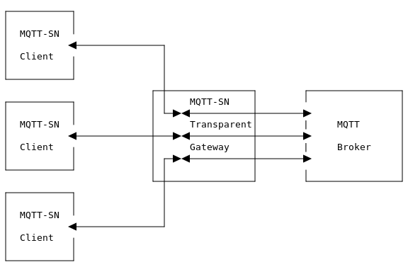

Because PUBWOS packets could be sent at any time by Clients with no Virtual Connection, a Transparent Gateway would need to maintain a dedicated MQTT connection with the MQTT Server to support those packets.

### C.1.2 Aggregating Gateway

Instead of having one MQTT connection for each connected MQTT-SN Client, an aggregating Gateway has one MQTT connection to the MQTT Server. All packet exchanges between an MQTT-SN client and an aggregating Gateway end at the Gateway. The Gateway then decides which information will be given further to the MQTT Server. Although its implementation may be more complex than a transparent Gateway, an aggregating Gateway reduces the number of MQTT connections between the Gateway and MQTT Server.

*Figure C-2 -- Aggregating Gateway*

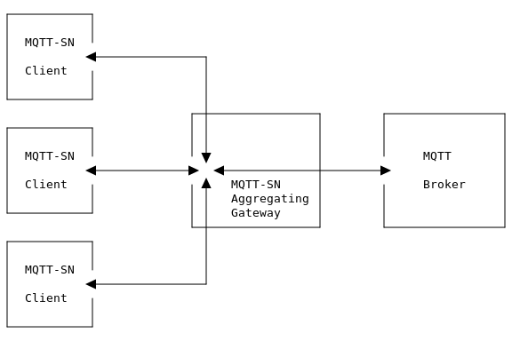

To support PUBWOS packets from MQTT-SN clients without a Virtual Connection, an Aggregating may use any aggregating MQTT connection to forward those packets to an MQTT Server.

A hybrid Gateway may contain elements of both Aggregating and Transparent Gateways, using different approaches depending on the characteristics of the MQTT-SN Clients connecting to them.

### C.1.3 Forwarder

An MQTT-SN Forwarder connects two networks which cannot transmit messages directly to and from each other. It serves as a bridge for MQTT-SN messages between the two networks, allowing MQTT-SN Clients in one to connect to an MQTT-SN Gateway in the other. The two networks could be Zigbee on one side and UDP on the other, for instance.

The following diagrams illustrate how a Forwarder may interact with an Aggregating or Transparent Gateway.

*Figure C-3 -- Forwarder with Transparent Gateway*

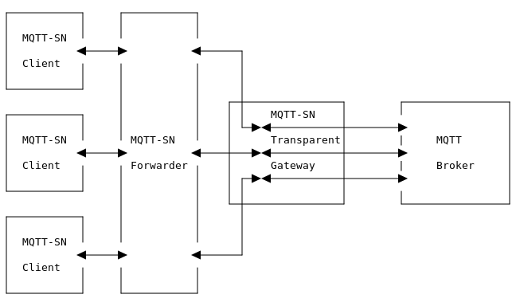

*Figure C-4 -- Forwarder with Aggregating Gateway*

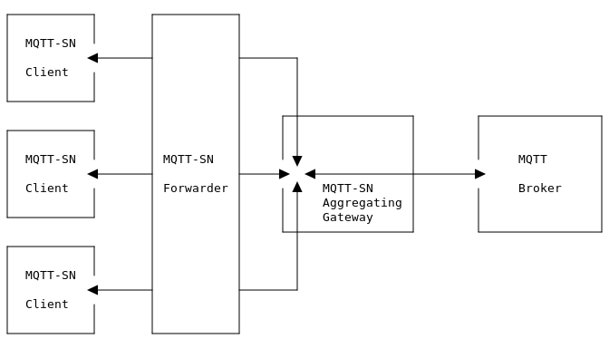

### C.1.4 MQTT-SN Broker

An MQTT-SN Server may have no interaction with an MQTT Server, in which case, much like an MQTT Server, it will act as an intermediary between MQTT-SN Clients.

It will allow MQTT-SN Clients to set up subscriptions, and publish messages to other clients which have subscribed to the relevant topics. It may support the receipt and sending of PUBWOS packets - it is an implementation decision on how to handle them.

*Figure C-5 -- MQTT-SN Broker*

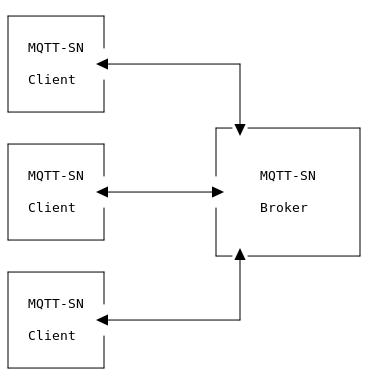

An MQTT-SN Server may choose to incorporate elements of a Broker, Aggregating and Transparent Gateway together. Typically, an Aggregating Gateway will also act as an MQTT-SN Broker.

## C.2 Server Congestion

For CONNECT, PUBLISH, SUBSCRIBE and REGISTER requests, the Server may return the Reason Code *Congestion*, meaning *try again later*.

The requester should wait a reasonable amount of time (*[Congestion Delay)]* before sending a new request to the Server. What constitutes *a reasonable amount of time* depends on the implementation characteristics - it should be configured in the client application based on those. See C.3 Example Timer and Counter Values for an example value.

## C.3 Example Timer and Counter Values

To balance reaction speed with reliability, the tolerance of the sleep timers at the Server may depend on the values indicated by the clients. For example, the timer values may be 10% higher than the indicated values for periods larger than 1 minute, and 50% higher if less.

## C.4 Exponential Backoff

The *Retry Interval* for unacknowledged packets can be increased on each retry, to avoid overwhelming recipient network nodes while allowing efficient Virtual Connection reestablishment. The client periodically retries a failed packet with increasing delays between attempts, constrained by a Maximum Retry Interval, interleaved with a suitable seed of randomness.

**Algorithm:**

This algorithm retries requests at doubling intervals, increasing time between retries up to a *Maximum Retry Interval*. For example:

1. Send initial packet sent. The initial *Retry Interval* is 1000 ms.
2. Wait up to 1000 + (random number) ms - retry the operation if no response is received during that time.
3. Wait up to 2000 + (random number) ms - retry the operation if no response is received during that time.
4. Wait up to 4000 + (random number) ms - retry the operation if no response is received during that time.
5. Continue increasing the *Retry Interval* each time, but no larger than *Max. Retry Interval.*
6. Continue waiting and retrying up to *Max. Retry Count* number of retries, without increasing the *Retry Interval* further.

The wait time is (ran is a random number, max is *Max. Retry Interval*):

min(((2^n * sf) + ran), max)

with n incremented by 1 for each iteration (or operation) and the scaling factor (sf) being set to some reasonable value - for example 1000 as in the example above.

The random number helps to avoid cases where many clients are synchronized by some situation, and all retry at once. The value of the random number ran is recalculated after each retry. The random number should be no larger than the initial *Retry Interval*.

## C.5 Client State Diagrams

The following diagrams are illustrative, graphical views of the states and transitions. They are not comprehensive but included for guidance.

*Figure C-7 -- Server View of Client States - informative*

[figure not shown]

*Figure C-8 -- Server View of Client States - informative*

[figure not shown]

## C.6 PUBLISH with QoS -1

*Figure C-9 -- PUBLISH Packet for QoS -1*

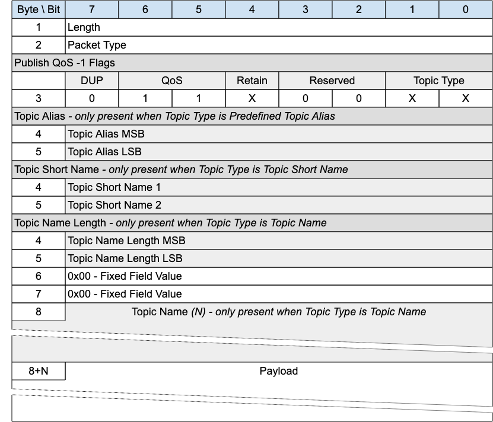

This packet is the MQTT-SN 1.2 equivalent of PUBWOS. It could be supported by a Server if there are existing MQTT-SN 1.2 transmitters that the Server wants to listen to, or receivers it wants to send to. Implementation of this packet is optional.

This packet can be used by both Clients and Servers to publish data to a topic without establishing a Virtual Connection or Session.

### C.6.1 PUBLISH Header

The first 2 or 4 bytes of the packet are encoded according to the variable length packet header format. Refer to 2.1 Structure of an MQTT-SN Control Packet for a detailed description.

### C.6.2 PUBLISH Flags

The PUBLISH Flags is a 1 byte field which contains flags specifying the content of the packet and the Server behavior. Bits 3-2 of the PUBLISH Flags are reserved and are set to 0.

The Client validates that the reserved flags in the PUBLISH packet are set to 0. If any of the reserved flags is not 0 it is a Malformed Packet.

#### C.6.2.1 Topic Type

**Position**: bits 0 and 1 of the PUBLISH Flags.

This determines the format of the Topic Data field.

The Topic Type in MQTT-SN 1.2 is different to that in MQTT-SN 2.0. The values applicable to PUBLISH QoS -1 are:

- 0b00 - Topic Name. Its length is defined in the Topic Name Length field.
- 0b01 - Predefined Topic Alias.
- 0b10 - Short Topic Name. A two byte Topic Name, with the same syntax as Topic Name. However, some 1.2 implementations treated this as a binary field.

#### C.6.2.2 QoS

**Position**: bits 5 and 6 of the PUBLISH Flags.

Set this field to "0b11" for QoS -1.

#### C.6.2.3 DUP

**Position**: bit 7 of the PUBLISH Flags.

Set to 0.

#### C.6.2.4 Retain

**Position**: bit 4 of the PUBLISH Flags.

This flag signifies whether the message is published as a retained message or not. See 4.13 Retained Messages for more information.

### C.6.3 Topic Alias

Only present if the Topic Type is Predefined Topic Alias. Contain a Topic Alias which is preconfigured to be known to both the sender and receiver.

### C.6.4 Topic Short Name

Only present if the Topic Type is Short Topic Name.

This is a two byte Topic Name. This Topic Type does not exist in later versions of MQTT-SN. It existed because the original MQTT-SN 1.2 did not allow a Long Topic Name, so the only other option for this packet was a Predefined Topic Alias.

### C.6.5 Topic Name Length

Only present if the Topic Type is Topic Name.

The length of the Topic Name field.

### C.6.6 Topic Name

Only present if the Topic Type is Topic Name.

Topic Name is a UTF-8 encoded string of length Topic Name Length.

### C.6.7 Payload

The Payload contains the payload data of the Application Message that is being published. The content and format of the data is application specific. It is valid for a PUBLISH packet to contain a zero length Payload.

### C.6.8 PUBLISH with QoS -1 Actions

The Client or Server uses a PUBLISH QoS -1 packet to send an Application Message to a Network Address, for possible receipt by a Server or another Client.

If received by a Client or Server, the PUBLISH QoS -1 packet is treated as if its QoS were 0 as described in 3.6.3.7 PUBLISH Actions.

## C.7 Gateway Advertisement and Discovery

Clients might have foreknowledge of how to reach a Gateway, but in dynamic networks they may not. MQTT-SN supports mechanisms to allow Clients to find available MQTT-SN Gateways. This support is optional - it may not be needed. In some implementations, the underlying network technology might be used for this purpose instead.

In MQTT-SN there are two principal ways for Clients and Gateways to find each other:

1. The Gateway can periodically transmit, or broadcast, an ADVERTISE packet to its neighborhood.
2. The Client can elicit a response from one or more Gateways, or Clients which know the network location of a Gateway, by broadcasting a SEARCHGW packet. The response, from either a Gateway or a Client on the Gateway's behalf, is a GWINFO packet.

A Gateway should only advertise its presence, or respond to SEARCHGW requests, if it is able to accept subscriptions and forward messages. For instance, a C.1.1 Transparent Gateway which is not currently connected to an MQTT Server, should not advertise.

Multiple Gateways may be active at the same time in the same network, in which case they will have different identifiers. It is up to the Client to decide to which Gateway it wants to connect.

A Client can maintain a list of active Gateways together with their network addresses. This list is populated with the information from ADVERTISE and GWINFO packets received.

The time until the Gateway sends the next ADVERTISE packet is indicated in the *Duration* field of the ADVERTISE packet (*[Advertise Duration]*). A Client may use this information to monitor the availability of a Gateway. For example, if it does not receive ADVERTISE packets from a Gateway several times (*[Advertise Count]*) consecutively, it may assume that the Gateway is down and remove it from its list of active Gateways. Similarly, Gateways in stand-by mode can become active (and start sending ADVERTISE packets) if they fail to observe successive advertisements from a previously active Gateway.

If the ADVERTISE packets are broadcast into the whole wireless network, the time interval between two consecutive ADVERTISE packets sent by a gateway should be large enough (greater than 15 minutes for example) to avoid bandwidth congestion in the network.

A large interval between ADVERTISE packets can lead to a long waiting time for new Clients which are looking for a Gateway. To shorten this waiting time a client may send a SEARCHGW packet. To prevent network flooding when multiple clients start searching for a Gateway almost at the same time, the sending of the SEARCHGW packet can be delayed by a random time *[SEARCHGW Delay]*. A client can cancel its transmission of the SEARCHGW packet if it receives during this delay time a SEARCHGW packet sent by another client and identical to the one it wants to send, and behaves as if the SEARCHGW packet was sent by itself.

Upon receiving a SEARCHGW packet a Gateway replies with a GWINFO packet containing its identifier. Similarly, a Client can answer with a GWINFO packet if it has at least one item in its active Gateway list. If the Client has multiple Gateways in its list, it can select one Gateway out of its list and include that information in the GWINFO packet.

To give priority to Gateways a client delays its sending of the GWINFO packet for a random time *[GWINFO Delay]*. If during this delay the Client receives a GWINFO packet it cancels the sending of its own GWINFO packet.

If there is no response, the SEARCHGW packet may be retransmitted. In this case the time intervals between consecutive SEARCHGW packets should be increased by an exponential backoff algorithm such as that described in C.4 Exponential Backoff.

# Appendix D. Revision History (informative)

[Optional section.]

Revisions made since the initial stage of this numbered Version of this document may be tracked here.

Note: If revision tracking is handled in another system like github, provide a link to it instead of using this table, if desired. Remove this note before submitting for publication.

| Revision | Date | Editor | Changes Made |
| --- | --- | --- | --- |
| WD-01 | 27th February 2020 | Andrew Banks | Merge Initial Document and Input Specification |
| WD-02 | 4th April 2020 | Andrew Banks Rahul Gupta | Terminology, DataTypes, CONNECT packet Specification Diagrams |
| WD-05 | 21st February 2021 | Simon Johnson | Packet Diagrams, Bit Tables, Field Definitions |
| WD-06 | 10th March 2021 | Simon Johnson | Sleeping client operational behavior, Terminology changes, 13 JIRA resolutions added to specification, Section numbering changes |
| WD-07 | 15th March 2021 | Simon Johnson | Added 4 byte (32 bit) integer description |
| WD-08 | 26th March 2021 | Simon Johnson | Added max packet size to CONNECT, Added Session Expiry Interval to CONNACK, Removed ZigBee references, Removed capabilities flag from CONNECT, AUTH packet added along with Authentication operational b… |
| WD-09 | 05th May 2021 | Simon Johnson | Added long topic type to topicIdTypes, updated PUBLISH to accommodate new topic type, added topic type matrix |
| WD-10 | October 2021 | Simon Johnson | Document format aligned with core specification, removal of introduction, addition of packet ID table, adding error code |
| WD-11 | October 2021 | Simon Johnson | MQTT-SN Architecture moved into operational behavior, removal of variable integer definition, addition of session state section, normative comments added to sleeping client operational behaviour |
| WD-12 | November 2021 | Andrew Banks | Rework 1.5 Background |
| WD-13 | November 2021 | Simon Johnson | Move Authentication and Retained messages into operational behavior, rationalized tables and figures, separated packet definitions of similar structures into distinct sections. |
| WD-14 | Decmeber 2021 | Simon Johnson | First implementation attempt, Fixed table references, Fixed PingResp packet |
| WD-15 | December 2021 | Simon Johnson | Tara added as editor, return code additions |
| WD-15 | February 2022 | Tara Walker | Changed Return Code nomenclature to be more consistent w/5.0. Added Reason Codes to each control packet type |
| WD-16 | March 2022 | Tara Walker | Updated WILL*Types to correct Packet Type. Added Global Flags Table to Section 2. Updated each Control Packet Flags in Section 3 adding missing Flag Sections. Formatting: Auto update of Table numberin… |
| WD-17 | April 2022 | Simon Johnson | Updated use of topic name and topic filter to be aligned with MQTT 5. Topic alias becomes topic alias type. Added quality of service protocol flow as it differed to MQTT 5 (inflight). Conformance refe… |
| WD-18 | June 2022 | Tara E. Walker | Updated items based upon the feedback from Alex Kritikos. |
| WD-19 | August 2022 | Simon Johnson | Remove change tracking as document was becoming unworkable. |
| WD-20 | September 2022 | Simon Johnson | Integrate feedback from committee meeting relating to the work by Miroslav Prymek. Added resolution of CONNACK session present per MQTT 585 |
| WD-21 | October 2022 | Simon Johnson | Client States section added to describe the 5 states. Updated the state transition diagram to accommodate new disconnect field and new transitions between Awake -> Lost and Asleep -> Disconnected. Sec… |
| WD-22 | November 2022 | Simon Johnson | Integrate MQTT 591 (sleep behavior) Replace instances of "return code" to "reason code" PINGREQ timeout aligned with Tretry (15 seconds) from the ill defined "reasonable amount of time" Exponential Al… |
| WD-23 | December 2022 | Simon Johnson | CONNECT Client Identifier Informative and Normative définition update. CONNACK Client Identifier Informative and Normative définition update. CONNACK reason codes updated. KeepAlive boundary specified… |
| WD-24 | December 2022 | Simon Johnson, Davide Lenzarini, Ian Craggs | Removal of Network Connection references. Modified PUBLISH -1 & 0 tables to remove topic length field Modified PUBLISH 1 & 2 tables to remove topic length field Changed Data field description on the a… |
| WD-25 | January 2023 | Simon Johnson | Broken out PUBLISH -1 into its own packet type Disconnect flags field moved and added existence flags for optional fields Introduction titles changed to better sign post where the information resides … |
| WD-26 | May 2023 | Simon Johnson, Davide Lenzarini | Backwards compatible PUBLISH -1, new OOS Publish message to repace it. Removal of security section to allow to rewrite. |
| WD-27 | November 2023 | Simon Johnson, Davide Lenzarini | Network Transport Layer chapter updated to define the impact of lower layers features on the MQTT-SN protocol. Replaced the term MQTT-SN "connection" with the term "Virtual Connection". |
| WD-28 | December 2023 | Davide Lenzarini, Stefan Hagen | Ensured document structure is intact and replaced table footnotes with simple text tags and a subsequent notes listing. |
|  | February 2024 | Ian Craggs, Simon Johnson | Issue 560 resolution - full reason code table and add reason code fields to PUBREC, PUBREL and PUBCOMP. Duplicate reason code tables removed from packet descriptions. Will Data Sent in CONNECT Auth Da… |
| WD-29 | March 2024 | Ian Craggs, Davide Lenzarini, Simon Johnson | Update Terminology section. Add Operational Behavior sections from MQTT 5.0. Workshop revisions to Operational Behavior responding to Davide's review. |
|  | June 2024 | Ian Craggs | Change CorrelId to Packet id. Move Virtual Connection semantics to Operational Behavior. Clarify MQTT-SN does not deduplicate. Do not preclude Unicast for PUBWOS. |
|  | July 2024 | Ian Craggs | Add Actions sections for all packets. Add a retained messages section. Add a flow control section. |
|  | August 2024 | Ian Craggs, Simon Johnson | Add WAKEUP packet. Update will firing conditions. Update retained messages terminology. |
|  | September 2024 | Ian Craggs | Remove one index level from the packet chapter. Disallow other packets before CONNACK. |
|  | October 2024 | Ian Craggs | Add SLEEPREQ and SLEEPRESP packets - disconnect now has no response. Rename Enhanced Authentication to Authentication. Add Gateway timer table. Add Security Chapter. |
|  | November 2024 | Ian Craggs | Add MQTT-BASIC authentication method. Move Appendices to main doc, except those that exist in MQTT. |
|  | February 2025 | Ian Craggs | Make session expiry in CONNACK optional. |
|  | March 2025 | Ian Craggs | Reformat all packet diagrams. Remove Topic Short Name. Simplify UN/SUBSCRIBE packet diagrams. Make session expiry in CONNECT optional. |
|  | April 2025 | Ian Craggs | Make Topic Alias in SUBACK optional. Move Retain Registrations from DISCONNECT to SLEEPREQ. Move informative Operational Behavior sections to Appendices. |
|  | May 2025 | Ian Craggs | Move Advertise, GWINFO and SEARCHGW to the end of Chapter 3. Move C.2 Advertisement and Discovery Appendix to end of Appendix C. Redraft Client States section. Add Server Keepalive to CONNACK. |
|  | June 2025 | Ian Craggs | Changed link format from section n.n to n.n xxxx. Updated PINGREQ actions. Reordered Control Packet Type to align with MQTT. Clarify definition and use of Server and Gateway terms. Removed radius fiel… |
|  | July 2025 | Ian Craggs | In the CONNACK packet: moved Default Awake Messages Flags to a byte field; added flags to allow Network ID update and Sleep Duration on SLEEPRESP. Added Sleep Duration and Reason Code to SLEEPRESP. Ad… |
|  | August 2025 | Ian Craggs, Davide Lenzarini | Removed Client ID from PINGREQ. Changed Allow Sleep Duration changes flag to apply to Keep Alive and Session Expiry too. Updated Sender Identifier description in Protection Encapsulation. Made Reason … |
|  | September 2025 | Ian Craggs | Added conformance statements to the Protection Encapsulation section. |
|  | October 2025 | Ian Craggs, Davide Lenzarini | Added Chapter 6 - Conformance. Updated Protection Encapsulation with corrections and conformance. Added conformance statement table to Appendix B. |

Table: Revisions made